# Topic3_rachel

## Topic 3: Determine collaboration patthern and connection mode for the repository of Agnet-Generated PRs

```python
%matplotlib inline

import networkx as nx
import numpy as np
from collections import defaultdict
import random
import plotly.graph_objects as go
import matplotlib.pyplot as plt
from matplotlib.colors import LinearSegmentedColormap
import community as community_louvain
import pandas as pd
from sklearn.preprocessing import StandardScaler
from sklearn.cluster import KMeans
import seaborn as sns
import os
from itertools import combinations
from mpl_toolkits.mplot3d import Axes3D
```

## Step1: Analysis Based on Efficiency and Popularity

To explore overall patterns in repository behavior, we applied a clustering analysis again using the two composite metrics constructed earlier—Efficiency and Popularity.

We first loaded the cleaned dataset (repo_activity.csv) and selected the key variables needed for clustering, including repository identifiers, activity scores, and several metadata fields. The Efficiency and Popularity columns were extracted as the feature matrix and standardized using StandardScaler, which ensures that both metrics contribute equally to the distance calculations in KMeans.

We then ran a KMeans model with five clusters, assigning each repository to a group based on its standardized feature values.

Finally, we visualized the clustering results by plotting Efficiency against Popularity, coloring each repository by its assigned cluster to reveal the overall distribution and structure of repository performance.

```python
data=pd.read_csv('repo_activity.csv')
```

```python
data.head()
```

|  | id | url | license | full_name | language | forks | stars | pr_count | merge_rate | contributors | review_density | merge_time | dominate_agent | merge_rate_score | merge_time_score | Efficiency | pr_count_score | contributors_score | review_comment_score | Popularity |
| --- | --- | --- | --- | --- | --- | --- | --- | --- | --- | --- | --- | --- | --- | --- | --- | --- | --- | --- | --- | --- |
| 0 | 987641962 | https://api.github.com/repos/1010-dev/senjudev... | 0 | 1010-dev/senjudev-site | TypeScript | 1.0 | 0.0 | 1 | 1.000000 | 1 | 0.0 | 572.567222 | Claude_Code | 100.000000 | 0.000000 | 60.000000 | 0.000000 | 0.000000 | 0.0 | 0.000000 |
| 1 | 990249393 | https://api.github.com/repos/106-/HellSinkerWa... | 0 | 106-/HellSinkerWallPaper | Java | 0.0 | 0.0 | 2 | 1.000000 | 1 | 0.0 | 0.147500 | Claude_Code | 100.000000 | 96.030733 | 98.412293 | 4.825684 | 0.000000 | 0.0 | 3.377979 |
| 2 | 1009549206 | https://api.github.com/repos/1genadam/tileshop... | 0 | 1genadam/tileshop-rag | Python | 0.0 | 0.0 | 1 | 1.000000 | 1 | 0.0 | 0.048889 | Claude_Code | 100.000000 | 98.633483 | 99.453393 | 0.000000 | 0.000000 | 0.0 | 0.000000 |
| 3 | 983546765 | https://api.github.com/repos/1kimnet/ETL-pipeline | 0 | 1kimnet/ETL-pipeline | Python | 0.0 | 0.0 | 37 | 0.432432 | 2 | 0.0 | 11.230382 | Copilot | 43.243243 | 27.486563 | 36.940571 | 35.043537 | 16.053392 | 0.0 | 26.135815 |
| 4 | 1024190983 | https://api.github.com/repos/20m61/lightningta... | 0 | 20m61/lightningtalk-circle | JavaScript | 0.0 | 0.0 | 7 | 0.857143 | 1 | 0.0 | 2.547454 | Claude_Code | 85.714286 | 63.338019 | 76.763779 | 16.499122 | 0.000000 | 0.0 | 11.549385 |

```python
data=data[['id','Efficiency','Popularity','stars','forks','pr_count','dominate_agent']]
```

```python
data
```

|  | id | Efficiency | Popularity | stars | forks | pr_count | dominate_agent |
| --- | --- | --- | --- | --- | --- | --- | --- |
| 0 | 987641962 | 60.000000 | 0.000000 | 0.0 | 1.0 | 1 | Claude_Code |
| 1 | 990249393 | 98.412293 | 3.377979 | 0.0 | 0.0 | 2 | Claude_Code |
| 2 | 1009549206 | 99.453393 | 0.000000 | 0.0 | 0.0 | 1 | Claude_Code |
| 3 | 983546765 | 36.940571 | 26.135815 | 0.0 | 0.0 | 37 | Copilot |
| 4 | 1024190983 | 76.763779 | 11.549385 | 0.0 | 0.0 | 7 | Claude_Code |
| ... | ... | ... | ... | ... | ... | ... | ... |
| 116206 | 1020305485 | 97.305683 | 0.000000 | 0.0 | 0.0 | 1 | Devin |
| 116207 | 976509925 | 98.247982 | 0.000000 | 0.0 | 0.0 | 1 | Devin |
| 116208 | 989288917 | 98.461481 | 10.436919 | 0.0 | 0.0 | 6 | Devin |
| 116209 | 915873255 | 0.000000 | 0.000000 | 0.0 | 0.0 | 1 | Devin |
| 116210 | 1000819309 | 69.376934 | 7.633728 | 0.0 | 0.0 | 4 | Devin |

116211 rows × 7 columns

```python
X = data[["Efficiency", "Popularity"]].copy()
# data normalization
scaler = StandardScaler()
X_scaled = scaler.fit_transform(X)

# setting cluster count
k = 5

# Kmeans
kmeans = KMeans(
    n_clusters=k,
    n_init=10,
    random_state=42
)

labels = kmeans.fit_predict(X_scaled)

# record cluster value
data = data.copy()
data["cluster"] = labels

print("KMeans finished.")
data.head()
```

```
KMeans finished.
```

|  | id | Efficiency | Popularity | stars | forks | pr_count | dominate_agent | cluster |
| --- | --- | --- | --- | --- | --- | --- | --- | --- |
| 0 | 987641962 | 60.000000 | 0.000000 | 0.0 | 1.0 | 1 | Claude_Code | 1 |
| 1 | 990249393 | 98.412293 | 3.377979 | 0.0 | 0.0 | 2 | Claude_Code | 1 |
| 2 | 1009549206 | 99.453393 | 0.000000 | 0.0 | 0.0 | 1 | Claude_Code | 1 |
| 3 | 983546765 | 36.940571 | 26.135815 | 0.0 | 0.0 | 37 | Copilot | 0 |
| 4 | 1024190983 | 76.763779 | 11.549385 | 0.0 | 0.0 | 7 | Claude_Code | 4 |

```python
X['Popularity'].max()
```

```
70.0
```

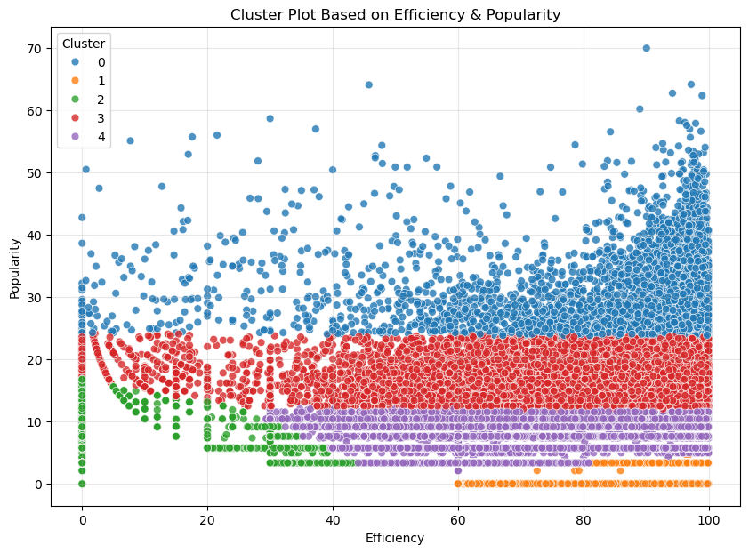

```python
plt.figure(figsize=(10, 7))

sns.scatterplot(
    data=data,
    x="Efficiency",
    y="Popularity",
    hue="cluster",
    palette="tab10",
    s=40,
    alpha=0.8
)

plt.title("Cluster Plot Based on Efficiency & Popularity")
plt.xlabel("Efficiency")
plt.ylabel("Popularity")
plt.legend(title="Cluster")
plt.grid(alpha=0.3)

plt.show()
```

## Step2:Filtering High-Value Repositories Based on Score Distributions

After examining the summary statistics of Efficiency and Popularity, as well as the cluster visualization from the previous step, it becomes clear that both metrics are highly skewed. Only a relatively small subset of repositories achieve meaningful scores in both dimensions.

To focus the analysis on repos that are genuinely active and impactful, we filtered the dataset to retain only entries with a Popularity score of at least 42 and an Efficiency score of at least 50. Given that the maximum possible Popularity value under our scoring rules is 70, this threshold selects repositories that rank in the upper performance range.

Some of the selected repositories still have low star or fork counts, suggesting that these projects may be primarily designed for AI agents rather than human users. The resulting filtered subset represents our final list of high-value repositories for deeper analysis.

```python
data['Efficiency'].describe()
```

```
count    116211.000000
mean         62.985951
std          42.801859
min           0.000000
25%           0.000000
50%          87.311700
75%          99.717390
max         100.000000
Name: Efficiency, dtype: float64
```

```python
data['Popularity'].describe()
```

```
count    116211.000000
mean          5.526521
std           7.859192
min           0.000000
25%           0.000000
50%           3.377979
75%           7.633728
max          70.000000
Name: Popularity, dtype: float64
```

From the cluster plot and data desciption, we can see that the data scoring is extremely skrewed, we will foucs on the repos that are truly popular and relatively efficient.

```python
temp=data[(data['Popularity']>=42) & (data['Efficiency']>=50)].copy()
temp
```

|  | id | Efficiency | Popularity | stars | forks | pr_count | dominate_agent | cluster |
| --- | --- | --- | --- | --- | --- | --- | --- | --- |
| 505 | 1001337788 | 96.823361 | 43.423588 | 0.0 | 0.0 | 366 | OpenAI_Codex | 0 |
| 905 | 845317529 | 54.921165 | 52.325420 | 154.0 | 36.0 | 139 | OpenAI_Codex | 0 |
| 961 | 21764480 | 95.294513 | 58.309717 | 167.0 | 104.0 | 421 | OpenAI_Codex | 0 |
| 1274 | 136202695 | 56.621614 | 50.913881 | 21402.0 | 4716.0 | 91 | Copilot | 0 |
| 2139 | 1000597137 | 85.590606 | 42.804458 | 0.0 | 1.0 | 280 | OpenAI_Codex | 0 |
| ... | ... | ... | ... | ... | ... | ... | ... | ... |
| 99011 | 734549019 | 88.095320 | 47.032898 | 1.0 | 0.0 | 565 | OpenAI_Codex | 0 |
| 99503 | 975676203 | 96.352094 | 46.469667 | 1.0 | 0.0 | 528 | OpenAI_Codex | 0 |
| 112247 | 496817075 | 83.930063 | 47.819792 | 951.0 | 54.0 | 97 | Devin | 0 |
| 113115 | 959682770 | 50.599784 | 47.248893 | 6643.0 | 1109.0 | 148 | Devin | 0 |
| 113117 | 941289933 | 51.877524 | 50.902285 | 537.0 | 186.0 | 171 | Devin | 0 |

249 rows × 8 columns

Due to the scoring rule of popularity, the max popularity value is 70, so we are taking the repos with popularity above 42 and efficiency above 50 as our final repo list. Note that some of the repos may have few stars and forks. This may indicate that these repos are espcially designed for AI agent and is not usually used by human.

## Step3:Building a Weighted Repository Network Based on Agent and User Co-Activity

To analyze how repositories are connected through shared development activity, we constructed a weighted network graph using only the high-value repositories identified in the previous step.

We began by filtering the full PR dataset to include only pull requests from these selected repositories, retaining key fields such as repo_id, agent, user_id, and merged_at. Each repository was then added to an undirected graph as a node, and we assigned Efficiency and Popularity scores as node attributes to support later visualization and analysis.

Edges between repositories were created based on co-activity: if the same agent contributed to multiple repositories, we added edges between those repos and incremented their weights by **1** for each shared agent. Similarly, if the same user ID appeared across multiple repositories—a stronger signal of shared ownership or collaboration—we increased the edge weights by an additional **3** for each such connection.

This process produced a weighted network that captures meaningful relationships among top-performing repositories, reflecting both agent-level and user-level interaction patterns.

```python
all_pr_df = pd.read_parquet("hf://datasets/hao-li/AIDev/all_pull_request.parquet")
```

```python
all_pr_df.head()
```

|  | id | number | title | body | agent | user_id | user | state | created_at | closed_at | merged_at | repo_id | repo_url | html_url |
| --- | --- | --- | --- | --- | --- | --- | --- | --- | --- | --- | --- | --- | --- | --- |
| 0 | 3264016139 | 1688 | `metta code` --> `metta clip` and additional p... | Remove unused `root_key` variable to fix ruff ... | Claude_Code | 37011 | jacklionheart | closed | 2025-07-25T18:15:36Z | 2025-07-25T19:17:23Z | 2025-07-25T19:17:23Z | 8.439884e+08 | https://api.github.com/repos/Metta-AI/metta | https://github.com/Metta-AI/metta/pull/1688 |
| 1 | 3264021033 | 41 | feat: Comprehensive ruff error resolution with... | ## 🎯 Mission Accomplished: 100% Ruff Error Res... | Claude_Code | 131842369 | Draco3310 | open | 2025-07-25T18:17:57Z | None | None | 9.920635e+08 | https://api.github.com/repos/Draco3310/Gal-Fri... | https://github.com/Draco3310/Gal-Friday2/pull/41 |
| 2 | 3264042289 | 1600 | Add Evals frontend implementation plan and HTM... | \nCreate comprehensive implementation plan for... | Claude_Code | 6766889 | justicart | closed | 2025-07-25T18:26:15Z | 2025-07-25T23:19:14Z | None | 9.267118e+08 | https://api.github.com/repos/bolt-foundry/bolt... | https://github.com/bolt-foundry/bolt-foundry/p... |
| 3 | 3264042318 | 1601 | Add 4 new BfDs components for Evals interface ... | \nPhase 1 component creation for the Evals fro... | Claude_Code | 6766889 | justicart | closed | 2025-07-25T18:26:16Z | 2025-07-25T23:19:11Z | None | 9.267118e+08 | https://api.github.com/repos/bolt-foundry/bolt... | https://github.com/bolt-foundry/bolt-foundry/p... |
| 4 | 3264067496 | 3 | 🚀 Complete Frontend-Backend API Integration wi... | ## 🎯 Summary\n\nThis PR completes the **fronte... | Claude_Code | 42357482 | twitchyvr | closed | 2025-07-25T18:39:14Z | 2025-07-25T18:48:47Z | 2025-07-25T18:48:47Z | 1.025871e+09 | https://api.github.com/repos/twitchyvr/Spaghetti | https://github.com/twitchyvr/Spaghetti/pull/3 |

```python
#extract neccesary information from data
new = all_pr_df[all_pr_df['repo_id'].isin(temp['id'])].copy()
new = new[['repo_id','agent','user_id','merged_at']]
```

```python
new.head()
```

|  | repo_id | agent | user_id | merged_at |
| --- | --- | --- | --- | --- |
| 222 | 1.001338e+09 | Claude_Code | 126367011 | 2025-07-08T23:43:52Z |
| 238 | 1.362027e+08 | Claude_Code | 17039389 | 2025-07-11T05:13:35Z |
| 1607 | 2.176448e+07 | Claude_Code | 1226946 | 2025-07-24T20:59:50Z |
| 1745 | 8.453175e+08 | Claude_Code | 31448 | 2025-07-01T02:30:39Z |
| 1930 | 8.453175e+08 | Claude_Code | 31448 | 2025-06-19T06:29:42Z |

```python
#Calculating connections between repos
temp['id'] = temp['id'].astype(int)
new['repo_id'] = new['repo_id'].astype(int)

# --- Step 1: Adding all repos as nodes ---
G = nx.Graph()
G.add_nodes_from(temp['id'].unique())

# --- Step 1.5: Giving nodes attributes ---
node_attr = (
    temp
    .set_index('id')[['Efficiency', 'Popularity']]
    .to_dict('index')
)
nx.set_node_attributes(G, node_attr)

# --- Step 2: adding weight for the connection by common agent ---
for agent, df_agent in new.groupby('agent'):
    repos = df_agent['repo_id'].unique()
    for a, b in combinations(sorted(repos), 2):
        if G.has_edge(a, b):
            G[a][b]['weight'] += 1
        else:
            G.add_edge(a, b, weight=1)

# --- Step 3: adding weight for the connection by common user ---
for user, df_user in new.groupby('user_id'):
    repos = df_user['repo_id'].unique()
    for a, b in combinations(sorted(repos), 2):
        if G.has_edge(a, b):
            G[a][b]['weight'] += 3
        else:
            G.add_edge(a, b, weight=3)
```

## Step4: Visualizing the Repository Interaction Network in 3D

To better understand the structural relationships among the selected high-value repositories, we created an interactive 3D graph visualization based on the weighted network constructed earlier.

Using the NetworkX graph G, which contains repo nodes enriched with Efficiency and Popularity attributes and edges weighted by shared agent and user contributions, we first generated a two-dimensional spring layout and extended it into three dimensions by adding random z-coordinates. Edge weighting was incorporated into the visualization by separating strong edges (weight ≥ 2) from weaker connections, rendering high-weight edges individually with color and thickness proportional to their normalized weight, while sampling weaker edges and displaying them in a unified light-gray layer to reduce visual clutter.

Node appearance was mapped to repository attributes: Efficiency was encoded using a continuous color scale, and Popularity was reflected in node size. Additional colorbars were included to interpret both node efficiency and edge strength.

The final 3D plot, built with Plotly, allows for rotation and interactive inspection, providing an intuitive view of how repositories cluster and connect through shared agent and user activity.

```python
%matplotlib widget
import matplotlib.pyplot as plt
```

```python
import networkx as nx
import numpy as np
from collections import defaultdict
import random
import plotly.graph_objects as go
import matplotlib.pyplot as plt
from matplotlib.colors import LinearSegmentedColormap


# ---------- 0. matplotlib colormap -> plotly colorscale ----------
def mpl_to_plotly(cmap, n=256):
    xs = np.linspace(0, 1, n)
    colors = cmap(xs)
    scale = []
    for x, (r, g, b, a) in zip(xs, colors):
        scale.append([float(x),
                      f"rgb({int(r*255)},{int(g*255)},{int(b*255)})"])
    return scale

# colormap：turbo
base = plt.cm.turbo
colors_turbo = base(np.linspace(0.1, 1.00, 256))
turbo_green_red = LinearSegmentedColormap.from_list(
    "turbo_green_red", colors_turbo
)
node_colorscale = mpl_to_plotly(turbo_green_red)

# edge inferno（
edge_cmap = plt.cm.inferno
edge_colorscale = mpl_to_plotly(edge_cmap)

# ---------- 1. setting 3d point position ----------
pos2d = nx.spring_layout(G, seed=42, k=1.0, iterations=75)

pos3d = {}
for n, (x, y) in pos2d.items():
    z = np.random.uniform(-1, 1)  # z
    pos3d[n] = (x, y, z)

# ---------- 2. setting edge for display, the edge number is too big, for edge with weight 5, we are randomly displaying 5 for each node ----------
edges_data = list(G.edges(data=True))

strong_edges = []             # weight >= 2
weak_incident = defaultdict(list)
edge_attr = {}

for u, v, d in edges_data:
    w = d.get("weight", 1)
    key = tuple(sorted((u, v)))
    edge_attr[key] = (u, v, d)

    if w >= 2:
        strong_edges.append((u, v, d))
    elif w == 1:
        weak_incident[u].append(key)
        weak_incident[v].append(key)

chosen_weak_keys = set()
max_weak_per_node = 5
random.seed(42)

for node, edge_keys in weak_incident.items():
    if len(edge_keys) <= max_weak_per_node:
        chosen = edge_keys
    else:
        chosen = random.sample(edge_keys, max_weak_per_node)
    chosen_weak_keys.update(chosen)

weak_edges_selected = [edge_attr[key] for key in chosen_weak_keys]

# ---------- 3. normalize edge weight for coloring ----------
all_w = np.array([d.get("weight", 1) for _, _, d in edges_data])
w_min, w_max = all_w.min(), all_w.max()

def norm_w(w):
    return (w - w_min) / (w_max - w_min + 1e-9)

# ---------- 4. weak edge trace（ 3D trace） ----------
edge_x_weak, edge_y_weak, edge_z_weak = [], [], []

for u, v, d in weak_edges_selected:
    x0, y0, z0 = pos3d[u]
    x1, y1, z1 = pos3d[v]
    edge_x_weak += [x0, x1, None]
    edge_y_weak += [y0, y1, None]
    edge_z_weak += [z0, z1, None]

edge_trace_weak = go.Scatter3d(
    x=edge_x_weak,
    y=edge_y_weak,
    z=edge_z_weak,
    mode='lines',
    line=dict(width=1, color='rgba(200,200,200,0.25)'),
    hoverinfo='none',
    showlegend=False
)

# ---------- 5. strong edge trace：3D  ----------
strong_edge_traces = []

for u, v, d in strong_edges:
    x0, y0, z0 = pos3d[u]
    x1, y1, z1 = pos3d[v]
    w = d.get("weight", 1)
    nw = norm_w(w)

    rgba = edge_cmap(nw)
    color_str = f"rgba({int(rgba[0]*255)},{int(rgba[1]*255)},{int(rgba[2]*255)},{rgba[3]:.2f})"

    trace = go.Scatter3d(
        x=[x0, x1],
        y=[y0, y1],
        z=[z0, z1],
        mode='lines',
        line=dict(
            width=2.0 + 4 * nw,
            color=color_str
        ),
        hoverinfo='none',
        showlegend=False
    )
    strong_edge_traces.append(trace)

# ---------- 6. node  ----------
nodes = list(G.nodes())
x_nodes = [pos3d[n][0] for n in nodes]
y_nodes = [pos3d[n][1] for n in nodes]
z_nodes = [pos3d[n][2] for n in nodes]

eff = np.array([G.nodes[n].get("Efficiency", 0) for n in nodes])
e_min, e_max = eff.min(), eff.max()
norm_eff = (eff - e_min) / (e_max - e_min + 1e-9)
gamma = 0.8
norm_eff_adj = norm_eff ** gamma   # 0~1，

pop = np.array([G.nodes[n].get("Popularity", 0) for n in nodes])
pop_scaled = 5 + 25 * (pop - pop.min()) / (pop.max() - pop.min() + 1e-9)

hover_text = [
    f"id: {n}<br>Efficiency: {G.nodes[n].get('Efficiency', 0):.2f}"
    f"<br>Popularity: {G.nodes[n].get('Popularity', 0):.2f}"
    for n in nodes
]

# ---------- 7. nodes 3D trace ----------
node_trace = go.Scatter3d(
    x=x_nodes,
    y=y_nodes,
    z=z_nodes,
    mode='markers',
    hoverinfo='text',
    text=hover_text,
    marker=dict(
        size=pop_scaled,
        color=norm_eff_adj,           # 0~1
        colorscale=node_colorscale,   # 浅绿 -> 红
        cmin=0, cmax=1,
        line=dict(width=0.5, color='black'),
        colorbar=dict(
            title="Efficiency",
            x=1.08
        )
    ),
    showlegend=False
)

# Edge Weight
edge_colorbar_dummy = go.Scatter3d(
    x=[None],
    y=[None],
    z=[None],
    mode='markers',
    marker=dict(
        size=0,
        color=[w_min, w_max],
        colorscale=edge_colorscale,
        cmin=w_min,
        cmax=w_max,
        colorbar=dict(
            title="Edge Weight",
            x=1.18
        )
    ),
    showlegend=False,
    hoverinfo='none'
)

# ---------- 8. all trace ----------
data = [edge_trace_weak] + strong_edge_traces + [node_trace, edge_colorbar_dummy]

fig = go.Figure(data=data)

fig.update_layout(
    width=1000,
    height=1600,
    title="Repo Graph 3D (drag to rotate, hover node for details)",
    showlegend=False,
    scene=dict(
        xaxis=dict(showbackground=False, visible=False),
        yaxis=dict(showbackground=False, visible=False),
        zaxis=dict(showbackground=False, visible=False),
        aspectmode='data'
    ),
)

fig.show()
```

[interactive chart not shown]

## Step5:Filtering Weak Connections and Extracting Core Repository Nodes

To refine the network and focus on meaningful structural relationships, we filtered the graph by removing all edges with a weight of 1, since these represent minimal or incidental connections.

After pruning these weak ties, we computed degree centrality to evaluate each repository’s relative importance within the remaining network.

We also removed isolated nodes—repositories that no longer had any connections after edge filtering—to retain only the core set of repos that participate in substantial shared activity.

Finally, we extracted all nodes with degree greater than zero to obtain the list of repositories that remain structurally relevant in the filtered network.

```python
edges_remove=[(u,v) for u,v,w, in G.edges(data='weight') if w==1]
G.remove_edges_from(edges_remove)
```

```python
deg=nx.degree_centrality(G)
```

```python
print(G)
```

```
Graph with 249 nodes and 238 edges
```

```python
G.remove_nodes_from(list(nx.isolates(G)))
```

```python
#After filtering all the weak edge and isolated nodes, we are having 54 repos left
print(G)
```

```
Graph with 54 nodes and 238 edges
```

```python
nodes_deg_gt1=[n for n,d in G.degree() if d>0]
print(nodes_deg_gt1)
```

```
[np.int64(1001337788), np.int64(845317529), np.int64(21764480), np.int64(136202695), np.int64(1000597137), np.int64(1015108803), np.int64(970331732), np.int64(985454802), np.int64(1001726147), np.int64(922867547), np.int64(981437432), np.int64(997625815), np.int64(970416658), np.int64(234231371), np…
```

```python
all_repo_df = pd.read_parquet("hf://datasets/hao-li/AIDev/all_repository.parquet")
```

```python
repo_info=all_repo_df[all_repo_df['id'].isin(nodes_deg_gt1)].copy()
```

```python
repo_info=repo_info.drop(columns=['url'])
```

```python
repo_info=pd.merge(repo_info,temp,on='id')
```

```python
repo_info = repo_info.drop(columns=["cluster",'stars_y','forks_y']).rename(columns={"forks_x": "forks", "stars_x": "stars"})
repo_info = repo_info.drop_duplicates(subset="id")
repo_info.head()
```

|  | id | license | full_name | language | forks | stars | Efficiency | Popularity | pr_count | dominate_agent |
| --- | --- | --- | --- | --- | --- | --- | --- | --- | --- | --- |
| 0 | 1001337788 | None | atariryuma/Everyone-s-Answer-Board | HTML | 0.0 | 0.0 | 96.823361 | 43.423588 | 366 | OpenAI_Codex |
| 1 | 845317529 | Apache-2.0 | giselles-ai/giselle | TypeScript | 36.0 | 154.0 | 54.921165 | 52.325420 | 139 | OpenAI_Codex |
| 2 | 21764480 | NOASSERTION | hmislk/hmis | HTML | 104.0 | 167.0 | 95.294513 | 58.309717 | 421 | OpenAI_Codex |
| 3 | 136202695 | Apache-2.0 | mlflow/mlflow | Python | 4716.0 | 21402.0 | 56.621614 | 50.913881 | 91 | Copilot |
| 4 | 1000597137 | MIT | AbuAli85/extra-contracts-yy | TypeScript | 1.0 | 0.0 | 85.590606 | 42.804458 | 280 | OpenAI_Codex |

## Step 6:Detecting Structural Communities Using the Louvain Algorithm

To uncover cohesive structural groups within the refined repository network, we applied the Louvain community detection algorithm.

Using edge weights as the optimization criterion, the algorithm partitions the graph into communities that maximize modularity, revealing clusters of repositories that share strong collaborative or behavioral connections.

After computing the partition, we grouped repositories by their assigned community and inspected the size and composition of each group.

For visualization, we generated a 2D spring layout and colored nodes according to their community labels, enabling a clear view of how repositories cluster based on shared agent and user activity. This step highlights the underlying structure of the repo network and identifies subgroups that operate more closely together.

```python
import community as community_louvain
partition = community_louvain.best_partition(G, weight='weight')
```

```python
print(partition)
```

```
{np.int64(1001337788): 1, np.int64(845317529): 1, np.int64(21764480): 1, np.int64(136202695): 2, np.int64(1000597137): 2, np.int64(1015108803): 2, np.int64(970331732): 2, np.int64(985454802): 2, np.int64(1001726147): 2, np.int64(922867547): 2, np.int64(981437432): 2, np.int64(997625815): 2, np.int64…
```

```python
from collections import defaultdict

groups = defaultdict(list)
for node, com in partition.items():
    groups[com].append(node)

for com, nodes in groups.items():
    print(f"Community {com}: {len(nodes)} nodes")
    print(nodes[:20])
    print("---")
```

```
Community 1: 17 nodes
[np.int64(1001337788), np.int64(845317529), np.int64(21764480), np.int64(1009061088), np.int64(993205592), np.int64(777051546), np.int64(950132973), np.int64(999102560), np.int64(643978507), np.int64(988570153), np.int64(400215964), np.int64(1013210218), np.int64(669466632), np.int64(965250949), np.…
---
Community 2: 16 nodes
[np.int64(136202695), np.int64(1000597137), np.int64(1015108803), np.int64(970331732), np.int64(985454802), np.int64(1001726147), np.int64(922867547), np.int64(981437432), np.int64(997625815), np.int64(970416658), np.int64(234231371), np.int64(941274176), np.int64(949218884), np.int64(1009862842), n…
---
Community 3: 2 nodes
[np.int64(625374086), np.int64(1018400369)]
---
Community 4: 2 nodes
[np.int64(1004302093), np.int64(1004305025)]
---
Community 6: 2 nodes
[np.int64(1002308452), np.int64(1009933657)]
---
Community 7: 3 nodes
[np.int64(1004086788), np.int64(1001353858), np.int64(1002040110)]
---
Community 8: 2 nodes
[np.int64(888893927), np.int64(1007417881)]
---
Community 9: 2 nodes
[np.int64(1004680858), np.int64(1004605844)]
---
Community 10: 2 nodes
[np.int64(986045546), np.int64(985555595)]
---
Community 0: 4 nodes
[np.int64(1007308309), np.int64(817096901), np.int64(1006232769), np.int64(995754354)]
---
Community 5: 2 nodes
[np.int64(1005774241), np.int64(160660004)]
---
```

```python
community_df = pd.DataFrame.from_dict(partition, orient="index", columns=["community"])
community_df.index.name = "repo"
```

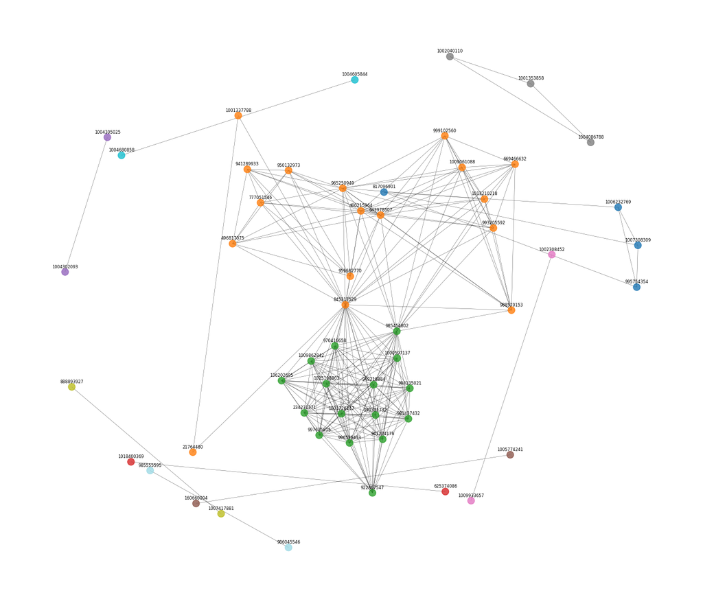

```python
%matplotlib inline
# 1. Community detection（Louvain）
partition = community_louvain.best_partition(G, weight='weight')

# 2. Coloring nodes
node_colors = [partition[n] for n in G.nodes()]

# 3. Spring layout
pos = nx.spring_layout(G, k=2.5, iterations=100, seed=42)

plt.figure(figsize=(14, 12))

nx.draw(
    G, pos,
    node_color=[partition[n] for n in G.nodes()],
    cmap=plt.cm.tab20,
    node_size=100,
    width=0.3,
    alpha=0.8
)

# drawing labels
labels = {n: n for n in G.nodes()}
label_pos = {n: (x, y+0.02) for n,(x,y) in pos.items()}  # 上移一点

nx.draw_networkx_labels(G, label_pos, labels=labels, font_size=6)
plt.axis("off")
plt.show()
```

```python
community_1_ids = groups[1]
community_2_ids = groups[2]
community_0_ids = groups[0]
community_7_ids = groups[7]
```

```python
communityA_df = repo_info[repo_info["id"].isin(community_1_ids)]
communityA_df
```

|  | id | license | full_name | language | forks | stars | Efficiency | Popularity | pr_count | dominate_agent |
| --- | --- | --- | --- | --- | --- | --- | --- | --- | --- | --- |
| 0 | 1001337788 | None | atariryuma/Everyone-s-Answer-Board | HTML | 0.0 | 0.0 | 96.823361 | 43.423588 | 366 | OpenAI_Codex |
| 1 | 845317529 | Apache-2.0 | giselles-ai/giselle | TypeScript | 36.0 | 154.0 | 54.921165 | 52.325420 | 139 | OpenAI_Codex |
| 2 | 21764480 | NOASSERTION | hmislk/hmis | HTML | 104.0 | 167.0 | 95.294513 | 58.309717 | 421 | OpenAI_Codex |
| 22 | 1009061088 | None | Tayler01/shadowChat1.0 | TypeScript | 0.0 | 0.0 | 96.779221 | 44.441158 | 341 | OpenAI_Codex |
| 31 | 993205592 | ISC | dashort/ride | JavaScript | 0.0 | 0.0 | 97.864568 | 45.829157 | 403 | OpenAI_Codex |
| 32 | 777051546 | NOASSERTION | denuoweb/QuestByCycle | Python | 1.0 | 1.0 | 95.700330 | 43.756022 | 314 | OpenAI_Codex |
| 33 | 950132973 | MIT | drivly/ai | TypeScript | 3.0 | 29.0 | 78.669073 | 54.468857 | 993 | Devin |
| 34 | 999102560 | MIT | gabriellagziel/appoint | Dart | 0.0 | 0.0 | 84.527565 | 45.502172 | 470 | OpenAI_Codex |
| 35 | 643978507 | MIT | langfuse/langfuse-docs | Jupyter Notebook | 117.0 | 128.0 | 67.766068 | 43.226542 | 70 | Cursor |
| 38 | 988570153 | None | mrjoncastro/admin-panel-umadeus | TypeScript | 0.0 | 0.0 | 91.691173 | 51.259157 | 939 | OpenAI_Codex |
| 39 | 400215964 | NOASSERTION | novuhq/novu | TypeScript | 4080.0 | 37349.0 | 60.356871 | 45.113256 | 80 | Devin |
| 40 | 1013210218 | None | patolina1000/-HotBotWebV2 | JavaScript | 0.0 | 0.0 | 99.068321 | 44.193925 | 331 | OpenAI_Codex |
| 43 | 669466632 | NOASSERTION | selfxyz/self | Circom | 116.0 | 691.0 | 50.152304 | 43.053170 | 63 | OpenAI_Codex |
| 50 | 965250949 | MIT | theopenco/llmgateway | TypeScript | 33.0 | 321.0 | 61.860416 | 46.880503 | 120 | Devin |
| 51 | 496817075 | MIT | GlareDB/glaredb | Rust | 54.0 | 951.0 | 83.930063 | 47.819792 | 97 | Devin |
| 52 | 959682770 | MIT | antiwork/gumroad | Ruby | 1109.0 | 6643.0 | 50.599784 | 47.248893 | 148 | Devin |
| 53 | 941289933 | MIT | antiwork/helper | TypeScript | 186.0 | 537.0 | 51.877524 | 50.902285 | 171 | Devin |

```python
communityB_df = repo_info[repo_info["id"].isin(community_2_ids)]
communityB_df
```

|  | id | license | full_name | language | forks | stars | Efficiency | Popularity | pr_count | dominate_agent |
| --- | --- | --- | --- | --- | --- | --- | --- | --- | --- | --- |
| 3 | 136202695 | Apache-2.0 | mlflow/mlflow | Python | 4716.0 | 21402.0 | 56.621614 | 50.913881 | 91 | Copilot |
| 4 | 1000597137 | MIT | AbuAli85/extra-contracts-yy | TypeScript | 1.0 | 0.0 | 85.590606 | 42.804458 | 280 | OpenAI_Codex |
| 5 | 1015108803 | MIT | Aries-Serpent/gh_COPILOT | Python | 0.0 | 1.0 | 95.705973 | 50.288612 | 689 | OpenAI_Codex |
| 6 | 970331732 | GPL-3.0 | CyanAutomation/judokon | JavaScript | 0.0 | 1.0 | 97.284687 | 52.935100 | 947 | OpenAI_Codex |
| 7 | 985454802 | Apache-2.0 | InterCooperative-Network/icn-core | Rust | 0.0 | 4.0 | 85.335991 | 51.624446 | 809 | OpenAI_Codex |
| 8 | 1001726147 | MIT | VimsRocz/IMU | Python | 0.0 | 4.0 | 92.745089 | 53.658537 | 1033 | OpenAI_Codex |
| 9 | 922867547 | MIT | charlesvestal/extending-move | Python | 5.0 | 79.0 | 73.094585 | 46.946777 | 461 | OpenAI_Codex |
| 10 | 981437432 | None | daparthi001/QuantumVestAI_App_Source_Code | Python | 0.0 | 0.0 | 91.423338 | 45.972272 | 410 | OpenAI_Codex |
| 11 | 997625815 | None | deveydtj/WWF | JavaScript | 0.0 | 0.0 | 90.971939 | 42.284550 | 263 | OpenAI_Codex |
| 12 | 970416658 | None | dmorazzini23/ai-trading-bot | Python | 0.0 | 1.0 | 97.733563 | 50.491383 | 706 | OpenAI_Codex |
| 13 | 234231371 | MIT | gofiber/fiber | Go | 1828.0 | 37269.0 | 52.941176 | 42.468950 | 51 | OpenAI_Codex |
| 14 | 941274176 | None | hbghlyj/kuing.cjhb.site | PHP | 1.0 | 0.0 | 91.104654 | 42.502573 | 270 | OpenAI_Codex |
| 15 | 949218884 | MIT | jdfalk/subtitle-manager | Go | 1.0 | 1.0 | 67.184571 | 44.681264 | 351 | OpenAI_Codex |
| 16 | 1009862842 | None | luckydizzier/wrecept | C# | 0.0 | 0.0 | 98.826127 | 46.727524 | 449 | OpenAI_Codex |
| 17 | 994135021 | None | ramadhan22/dropship-erp | Go | 0.0 | 0.0 | 91.664755 | 46.212033 | 422 | OpenAI_Codex |
| 18 | 996535413 | MIT | thesavant42/retrorecon | Python | 2.0 | 4.0 | 95.776975 | 51.746964 | 821 | OpenAI_Codex |

```python
communityC_df = repo_info[repo_info["id"].isin(community_0_ids)]
communityC_df
```

|  | id | license | full_name | language | forks | stars | Efficiency | Popularity | pr_count | dominate_agent |
| --- | --- | --- | --- | --- | --- | --- | --- | --- | --- | --- |
| 44 | 1007308309 | BSD-2-Clause | splanck/vc | C | 0.0 | 0.0 | 97.521122 | 52.755913 | 1124 | OpenAI_Codex |
| 45 | 817096901 | BSD-2-Clause | splanck/vento | C | 0.0 | 0.0 | 99.007967 | 46.164934 | 509 | OpenAI_Codex |
| 46 | 1006232769 | BSD-2-Clause | splanck/vlibc | C | 0.0 | 0.0 | 97.873944 | 48.069584 | 640 | OpenAI_Codex |
| 47 | 995754354 | BSD-2-Clause | splanck/vush | C | 0.0 | 0.0 | 98.525339 | 49.532015 | 763 | OpenAI_Codex |

```python
communityD_df = repo_info[repo_info["id"].isin(community_7_ids)]
communityD_df
```

|  | id | license | full_name | language | forks | stars | Efficiency | Popularity | pr_count | dominate_agent |
| --- | --- | --- | --- | --- | --- | --- | --- | --- | --- | --- |
| 25 | 1004086788 | None | adrianwedd/AI-SWA | Python | 1.0 | 0.0 | 99.565719 | 42.255809 | 318 | OpenAI_Codex |
| 26 | 1001353858 | NOASSERTION | adrianwedd/Agentic-Index | Python | 0.0 | 1.0 | 94.377032 | 42.385378 | 323 | OpenAI_Codex |
| 27 | 1002040110 | MIT | adrianwedd/agentic-research-engine | Python | 0.0 | 0.0 | 98.301230 | 45.140678 | 450 | OpenAI_Codex |

# Final Analysis of Contributor-Based Communities in the AI Agent Ecosystem

## 2. Shared Characteristics of the Two Large Communities

Despite addressing different layers of the AI engineering stack, the two major communities share several fundamental traits that define them as the “core ecosystem hubs” of the AI‑agent developer network.

### **2.2 Repository Topology: “Core Repository + Peripheral Satellites”**

Both large communities exhibit a **hub‑and‑spoke topology**:

- A small number of highly starred, publicly visible repositories (e.g., *mlflow/mlflow*, *gofiber/fiber*, *langfuse-docs*) function as the **public-facing cores**.
- These are surrounded by a large number of **low‑star, low‑fork but high‑PR‑activity** repositories representing auxiliary tools, experimental features, integration layers, or personal engineering sandboxes.

This indicates that contributors maintain a **professional, multi-repository workflow**, where a dominant “main project” is supported by numerous smaller codebases.

### **2.3 Multi‑Language Engineering Environment**

Both major communities operate within a **multi‑language, multi‑layered technical ecosystem**.  
Languages commonly include TypeScript, JavaScript, Python, Go, Rust, C#, and occasionally PHP or Ruby.  
This diversity suggests that contributors are engaged in **full-stack AI engineering**, spanning:

- front-end interfaces,
- backend orchestration layers,
- model-serving gateways,
- performance-critical modules,
- and domain-specific utilities.

### **2.4 Open Licensing Culture with Experimental Subspaces**

Licenses across the two major communities are dominated by **MIT** and **Apache-2.0**, but also include several repositories with *None* or *NOASSERTION*.  
This mixture indicates:

1. A **commitment to permissive open-source practices**, and
2. The presence of **rapid prototyping spaces**, where licensing has not yet stabilized.

## 3. Distinct Roles of the Two Large Communities

### **3.1 Community A: Web‑Oriented AI Agent Engineering**

The first large community clusters around repositories involving:

- agent dashboards and control panels,
- LLM gateways,
- front-end interaction systems,
- observability and logging documentation.

It leans heavily toward **TypeScript/JavaScript ecosystems**, indicating an emphasis on UI/UX, web orchestration, and agent-facing user layers.

### **3.2 Community B: ML‑Oriented AI Engineering and Traditional DevOps**

The second large community centers around:

- MLflow and similar ML engineering frameworks,
- general Python-based AI applications,
- high-performance Go infrastructure (e.g., *fiber*),
- small automation or analytic tools.

This community reflects a hybrid between **traditional ML engineers** and **agent-augmented developers**, with Copilot appearing as an additional agent in classical ML workflows.

## 4. Characteristics of the Two Small Communities

The two small communities diverge from the structural complexity of the large ones.  
Both are **internally homogeneous** and represent *localized development clusters*, typically tied to a single author or a single organization.

### **4.1 Community C (splanck/*): C-Based Toolchain Cluster**

This community contains several C-language repositories entirely belonging to the *splanck/* namespace, all licensed under BSD‑2-Clause.  
Their extremely high PR counts but zero public stars/forks suggest internal or specialized system-level codebases.  
All rely exclusively on **OpenAI Codex**, demonstrating a strong preference for AI-assisted low-level code generation in a controlled, focused environment.

### **4.2 Community D (adrianwedd/*): Python Agentic Computing Projects**

This community contains several Python repositories under the *adrianwedd/* namespace, each involving “Agentic” terminology or AI research tools.  
These repositories also exhibit very low public visibility but high internal development activity.  
Again, Codex is the sole agent used, pointing to a consistent workflow by a single developer or a tightly coordinated small team.

## 5. Large vs Small Community Comparison

[output not shown]

The distinction suggests that large communities represent **ecosystem‑defining collaboration zones**, while small communities represent **focused, local development micro-ecosystems**.

## 6. Final Synthesis

1. **At the center**, two large communities act as hubs for full-stack AI infrastructure and ML engineering.  
   They integrate diverse languages, rely heavily on OpenAI Codex, and maintain complex ecosystems of primary and auxiliary repositories.
2. **At the periphery**, two small communities represent localized clusters—cohesive, internally uniform, and driven by consistent agent usage patterns—highlighting how individual developers or small groups adopt AI agents to maintain specialized or experimental codebases.

Overall, the contributor graph exposes a clear **division of labor** within the agent-enhanced engineering ecosystem:  
**large communities shape shared infrastructure and widely used tools**, while **small communities innovate locally or specialize in niche workflows**.  
The dominance of Codex across all communities further emphasizes its central role as the primary agent used by developers for real-world coding tasks.